# Homework 5

Michael Toledano

2/25/2022

# Question 1

### a)

Write a function that returns the fifth element of a vector. If the vector has a length smaller than 5, return a string that says “The input vector is too small!”.

```r
get_fifth = function(vector){
  if(length(vector) >= 5){
    return(vector[5])
  }
  if(length(vector) < 5){
    print("The input vector is too small!")
  }
}

get_fifth(c(1,2,3,4,10))
```

```
## [1] 10
```

```r
get_fifth(c("A", "B"))
```

```
## [1] "The input vector is too small!"
```

### b)

Write a function that takes two arguments, `df` and `graph_type`. If `graph_type` equals “histogram”, make a histogram; if graph_type equals “box plot” make a boxplot. The input `df` is a dataframe and the variable to graph will always be `obs`. Test your function by creating a histogram and a box plot of the dataset found in `data/distro_sim.csv`.

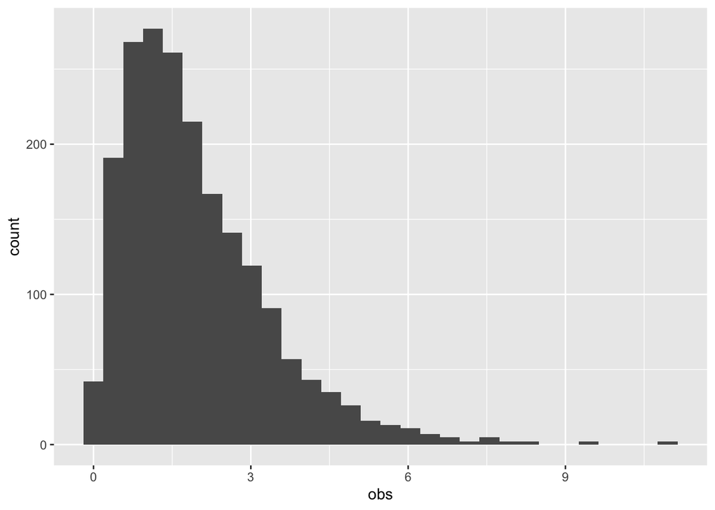

```r
make_plot <- function(df, graph_type){
  if(graph_type == "histogram"){
    histogram <- ggplot(data = df) +
      geom_histogram(aes(x = obs))
    return(histogram)
  }
  if(graph_type == "box plot"){
    boxplot <- ggplot(data = df) +
      geom_boxplot(aes(y = obs))
    return(boxplot)
  }
}

distro_data <- read_csv("data/distro_sim.csv")

make_plot(distro_data, "histogram")
```

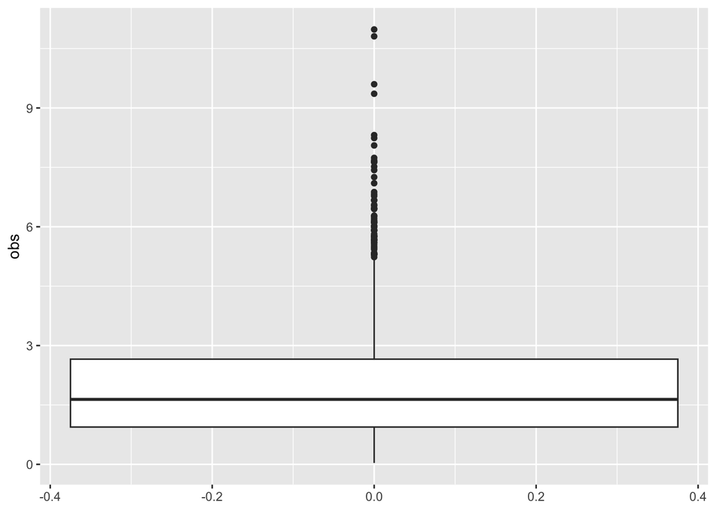

```r
make_plot(distro_data, "box plot")
```

### c)

Improve the graphs from part (b) by altering their themes, colors, titles, labels, or axes. Make two improvements to each graph and then create a histogram and box plot of the `data/distro_sim.csv` dataset. Explain your improvements in sentences below your new graphs.

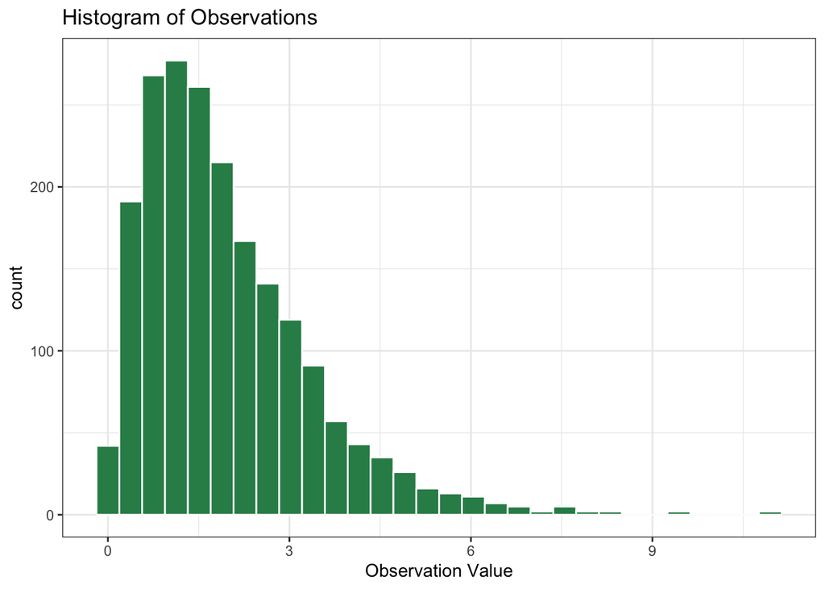

```r
make_plot_improved <- function(df, graph_type){
  if(graph_type == "histogram"){
    histogram <- ggplot(data = df) +
      geom_histogram(aes(x = obs), fill = 'seagreen', color = "white") +
      theme_bw() +
      labs(title = "Histogram of Observations", x = "Observation Value")
    return(histogram)
  }
  if(graph_type == "box plot"){
    boxplot <- ggplot(data = df) +
      geom_boxplot(aes(y = obs), fill = "light blue")+
      theme_bw() +
      labs(title = "Boxplot of Observations", y = "Observation Value")
    return(boxplot)
  }
}



distro_data <- read_csv("data/distro_sim.csv")

make_plot_improved(distro_data, "histogram")
```

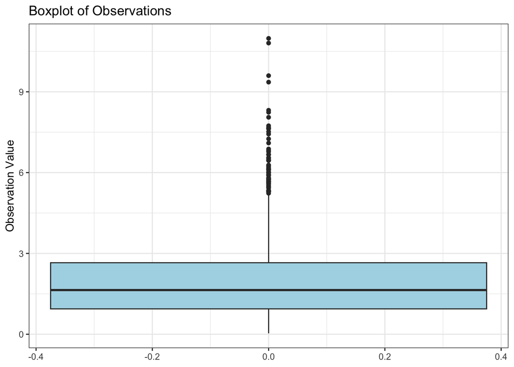

```r
make_plot_improved(distro_data, "box plot")
```

Answer:

For both the boxplot and histogram we added a title an axis label, changed the fill, and removed the grey background by applying theme_bw().

# Question 2

### a)

The code below contains a function which calculates power. This function contains errors which prevent it from behaving correctly and needs debugging. Rename and debug this function so it works correctly.

```r
# Old code

foofoo <- function(alt_mu, null_mu, s, n){
  alt_z <-(alt_mu - null_mu)/(s/sqrt(n))
  alt_hypothesis <- rnorm(alt_z, 1, 10000)
  alt_tibble <- tibble(obs = alt_hypothesis, scenario = "Alternative Hypothesis") %>%
    mutate(region <- if_else(obs < - 1.96 & obs > 1.96, "rejection", "non-rejection"))

  power_df <- alt_tibble %>%
    group_by(region) +
    summarize(n_total = n()) %>%
    mutate(proportion = n_total/sum(alt_z))

  power <- power_df %>%
    filter(region == "rejection") %\%
    pull(proportion) %>%
    round(4)
return(power)
}

# Corrected Code:
calculate_power <- function(alt_mu, null_mu, s, n){  #rename function
  alt_z <-(alt_mu - null_mu)/(s/sqrt(n))
  alt_hypothesis <- rnorm(10000, alt_z, 1) #10000 is first argument
  alt_tibble <- tibble(obs = alt_hypothesis, scenario = "Alternative Hypothesis") %>%
    mutate(region = if_else(obs < - 1.96 | obs > 1.96, "rejection", "non-rejection")) #or not and; region = not ->
  power_df <- alt_tibble %>%
    group_by(region) %>% #pipe not plus
    summarize(n_total = n()) %>%
    mutate(proportion = n_total/sum(n_total)) #divide by sum of n_total

  power <- power_df %>%
    filter(region == "rejection") %>%   #pipe incorrect
    pull(proportion) %>%
    round(4)
return(power)

}
```

### b)

Test the corrected function from (a) using the following inputs: alt_mu = 45, null_mu = 40, s = 4, n = 15. Report the power in a sentence.

```r
power_calc <- calculate_power(45, 40, 4, 15)
```

Answer:

The power for the above scenario is approximately 0.9975.

# Question 3

You have received four separate datasets for a small study on the effectiveness of a new drug on depression and anxiety. The first dataset contains demographic data collected at admission and is saved as `data/study832_demos.csv`. The second dataset contains randomization information and is saved as `data/study832_randomization.csv`. The third dataset contains measurements of HAM-D and HAM-A at baseline and is saved as `data/study832_baseline.csv". The fourth dataset contains measurements of HAM-D and HAM-A at the end of the study and is saved as`data/study832_study_end.xlsx`.

### a)

Load all four datasets into your R environment. Take a look at each dataset and report the primary key (unique identifier) of each dataset.

```r
demographics <- read_csv("data/study832_demos.csv")
rand <- read_csv("data/study832_randomization.csv")
baseline <- read_csv("data/study832_baseline.csv")
outcome <- read_excel("data/study832_study_end.xlsx", sheet = 3)
```

Answer:

The primary key for the demographics dataset is study_id; the primary key for the randomization dataset is patient_id; the primary key for the baseline dataset is id; and the primary key for the outcome dataset is study_id.

### b)

Join the demographic and randomization data frames together. Use a join that will drop any individuals who were not randomized.

```r
demo_rand <- rand %>%
  left_join(demographics, by = c("patient_id" = "study_id"))
```

### c)

Join the data frame from (b) with the baseline HAM-D and HAM-A dataset. Use a join that will drop any individuals who were not in the data frame from (b).

```r
base_demo_rand <- demo_rand %>%
  left_join(baseline, by = c("patient_id" = "id"))
```

### d)

Using the data frame from (c), join the outcome data from the `study832_study_end.xlsx` file and create new change score variables for change in HAM-D and change in HAM-A (the score at the end of the study minus the score at baseline). Use a join that will drop any individuals who were not in the data frame from (c). How many observations are missing values for HAM-A change and how many observations are missing values for HAM-D change?

```r
study_data <- base_demo_rand %>%
  left_join(outcome, by = c("patient_id" = "study_id"))

study_data_m <- study_data %>%
  mutate(change_hamd = outcome_hamd - baseline_hamd,
         change_hama = outcome_hama - baseline_hama)

missing_hama_change <- study_data_m %>%
  filter(is.na(change_hama)) %>%
  nrow()

missing_hamd_change <- study_data_m %>%
  filter(is.na(change_hamd)) %>%
  nrow()
```

Answer:

There are 28 observations missing for HAM-A change and there are 28 observations missing for HAM-D change.

### e)

Create two boxplots: one which shows the distribution of HAM-A changes scores by treatment group, and one that shows HAM-D change scores by treatment group.

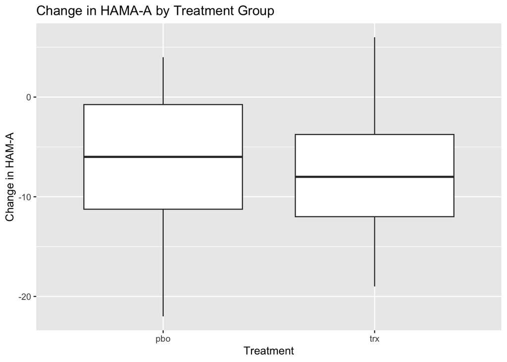

```r
ggplot(data = study_data_m) +
  geom_boxplot(aes(x = trx, y = change_hama)) +
  xlab("Treatment") + ylab("Change in HAM-A") +
  labs(title = "Change in HAMA-A by Treatment Group")
```

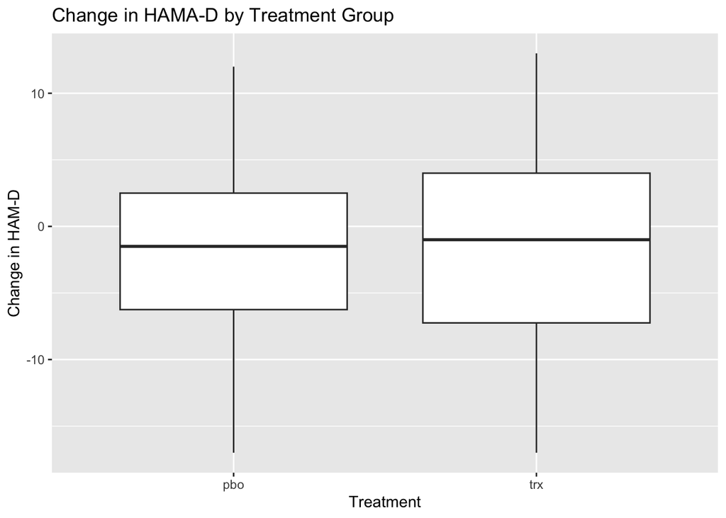

```r
ggplot(data = study_data_m) +
  geom_boxplot(aes(x = trx, y = change_hamd)) +
  xlab("Treatment") + ylab("Change in HAM-D") +
  labs(title = "Change in HAMA-D by Treatment Group")
```

### f)

Use t-tests (unequal variance) to test the difference between treatment groups for change in HAM-D scores and change in HAM-A scores. Be sure to report the test statistic, p-value, and degrees of freedom for each test in your write-up.

```r
hama_test <- t.test(change_hama ~ trx, data = study_data_m)

hamd_test <- t.test(change_hamd ~ trx, data = study_data_m)
```

Answer:

1. HAM-A: the test statistic is 0.81, the df is 34.79, and the p-value is 0.4262. Therefore, we do not have enough evidence to reject the null hypothesis that the mean change in HAMA-A is equal between the treatment and placebo groups.
2. HAM-D: the test statistic is -0.12, the df is 37.96, and the p-value is 0.9047. Therefore, we do not have enough evidence to reject the null hypothesis that the mean change in HAMA-D is equal between the treatment and placebo groups.

# Question 4

********THIS WAS NOT COVERED IN THE COURSE********

Let’s show the Central Limit Theorem in action!

It will be so much fun, it won’t even feel like a homework problem!

The CLT states that as we take more and more samples from ANY distribution, the distribution of the mean of these samples will approach a normal distribution.

### a)

Simulate two normal distributions and combine them into a tibble to create a bimodal distribution. To do this, create one tibble of 50,000 observations from a normal distribution with mean = 0 and sd = 1, and one tibble of 50,000 observations from a normal distribution with a mean between 5 and 10 and a standard deviation between 1 and 2 (you choose). Combine your simulated datasets using `bind_rows()`.

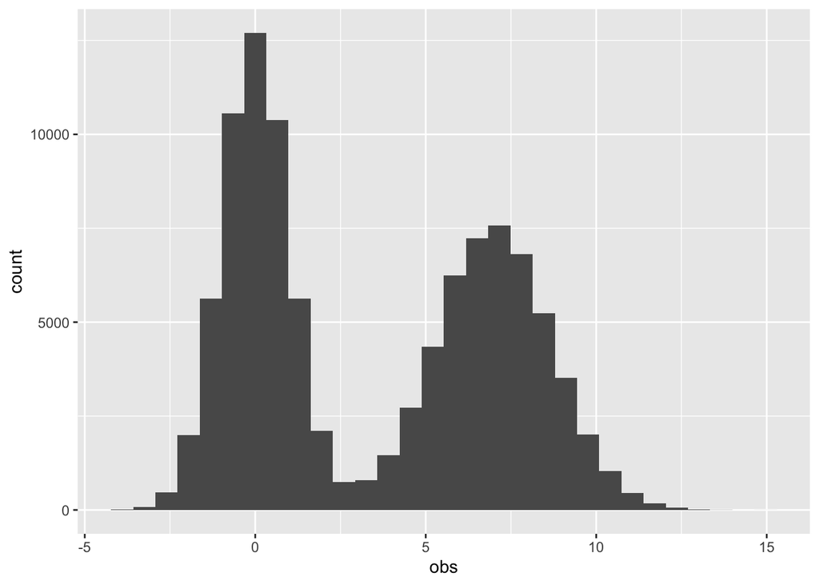

```r
standard_normal <- rnorm(50000, mean = 0, sd = 1)
standard_tibble <- tibble(obs = standard_normal)

other_normal <- rnorm(50000, mean = 7, sd = 1.7)
other_tibble <- tibble(obs = other_normal)

bimod_tibble <- bind_rows(other_tibble, standard_tibble)

ggplot(data = bimod_tibble) +
    geom_histogram(aes(x = obs))
```

### b)

Use the function below called `get_mean()` on the bimodal distribution you created – it will randomly sample n observations from a dataframe that you pass into it and calculate their mean, which gets returned in a dataframe. Notice that it expects the variable “obs” to be present in the input dataframe. You can alter the function to use the name of the variable you assigned in your tibble from (a) or you can rename the variable name from (a) to get this function to work. Run the function 5 times to show that it is working.

```r
get_mean <- function(input_df, n){
  s <- sample_n(input_df, size = n, replace = FALSE) %>%
    summarize(mean = mean(obs))
    return(s)
}

get_mean(other_tibble, 21)
```

```
## # A tibble: 1 × 1
##    mean
##   <dbl>
## 1  7.37
```

```r
get_mean(other_tibble, 6)
```

```
## # A tibble: 1 × 1
##    mean
##   <dbl>
## 1  6.93
```

```r
get_mean(other_tibble, 30)
```

```
## # A tibble: 1 × 1
##    mean
##   <dbl>
## 1  6.74
```

```r
get_mean(other_tibble, 3)
```

```
## # A tibble: 1 × 1
##    mean
##   <dbl>
## 1  6.17
```

```r
get_mean(other_tibble, 12)
```

```
## # A tibble: 1 × 1
##    mean
##   <dbl>
## 1  7.29
```

### c)

Write a function called `make_histogram()` that takes a dataframe as input and outputs a histogram. Make sure it will work on the results of the `get_mean()` function above – this means it should map the x aesthetic to the appropriate variable which represents the mean of the random sample you produce in the `get_mean()` function. Include an additional argument to your function that allows you to change the title of the histogram.

```r
make_histogram <- function(df, t){
  histogram_plot <- ggplot(data = df) +
                geom_histogram(aes(x = mean), bins = 75) +
                theme_stata() +
                labs(title = t)
  return(histogram_plot)
}
```

### d)

Now, use the `map_dfr()` function to obtain 10000 means from your bimodal distribution with varied sample sizes. Start with 10000 means of 2 random samples, then try 10000 means of 5, 10, 20, and 30 random samples. Each time you obtain your 10000 means, use your `make_histogram()` function to plot the distribution of your means. Make sure you add a title to each histogram so that we can tell how many samples you have drawn to get these means.

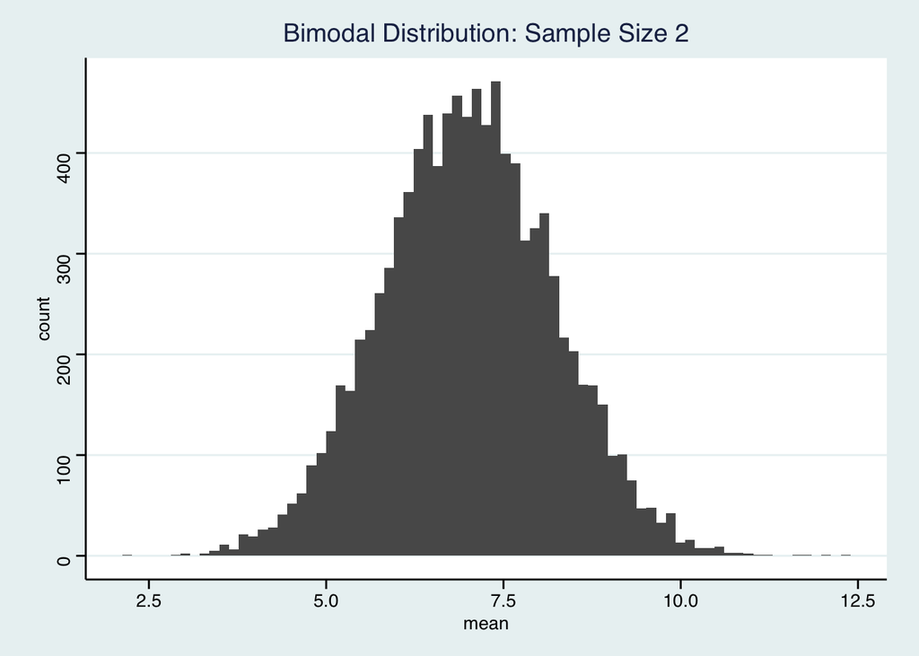

```r
bimodal_means_2 <- map_dfr(1:10000, function(x) get_mean(other_tibble,2))
make_histogram(bimodal_means_2, t = "Bimodal Distribution: Sample Size 2")
```

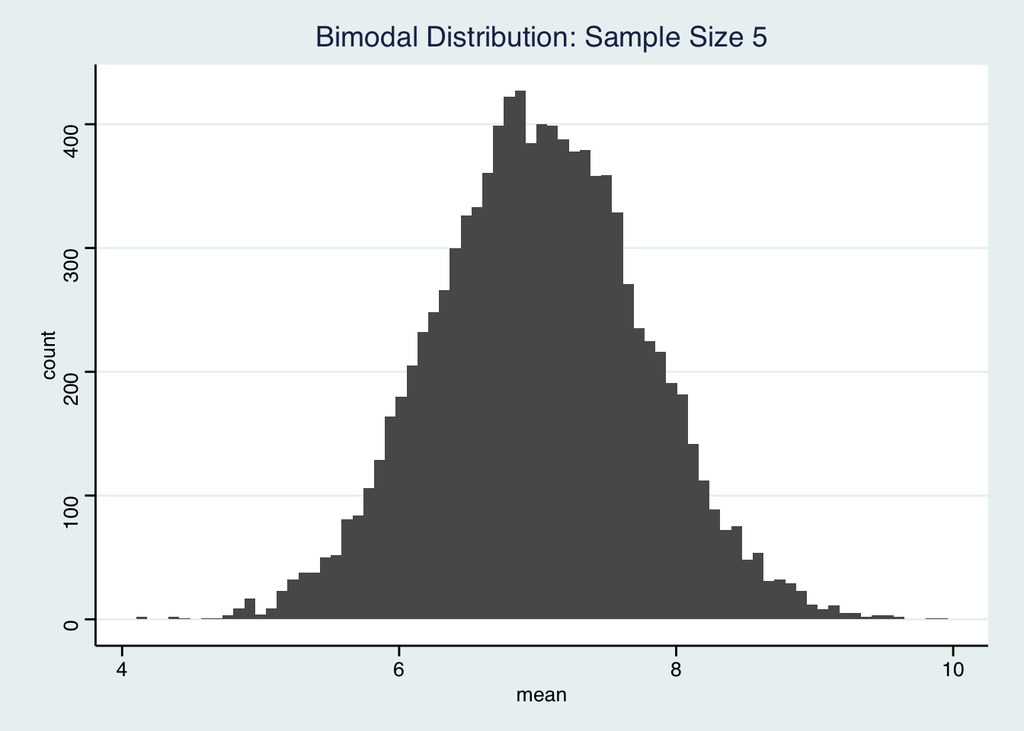

```r
bimodal_means_5 <- map_dfr(1:10000, function(x) get_mean(other_tibble, 5))
make_histogram(bimodal_means_5, t = "Bimodal Distribution: Sample Size 5")
```

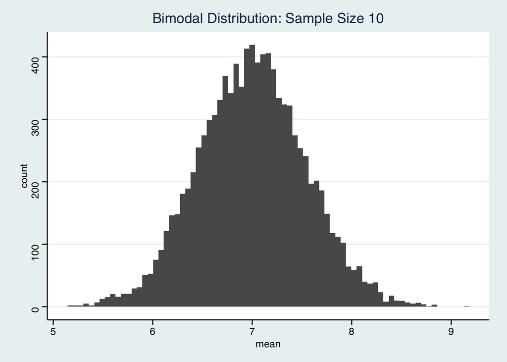

```r
bimodal_means_10 <- map_dfr(1:10000, function(x) get_mean(other_tibble, 10))
make_histogram(bimodal_means_10, t = "Bimodal Distribution: Sample Size 10")
```

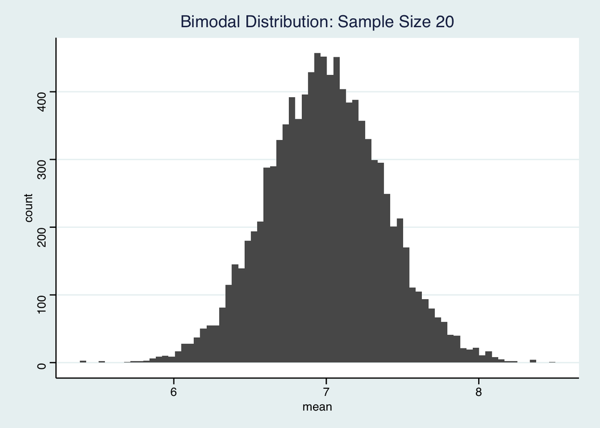

```r
bimodal_means_20 <- map_dfr(1:10000, function(x) get_mean(other_tibble, 20))
make_histogram(bimodal_means_20, t = "Bimodal Distribution: Sample Size 20")
```

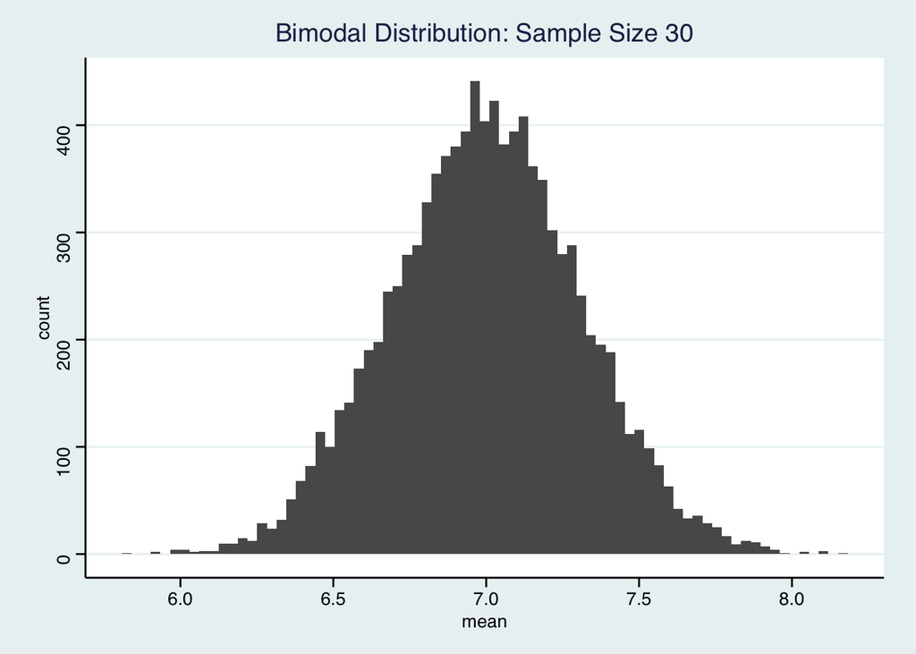

```r
bimodal_means_30 <- map_dfr(1:10000, function(x) get_mean(other_tibble, 30))
make_histogram(bimodal_means_30, t = "Bimodal Distribution: Sample Size 30")
```

### e)

Based on your results from part (d) above, does the Central Limit Theorem hold? How many samples did you need to use to obtain a distribution of means that approached the normal distribution?